# DVIAssignment

### DVI_GROUP006

### Fill in your BITS Registration ID, # Fill in your full name

Ponvani : 2018AC04559  
Poornima J : 2018AC04550  
Venkataramanan Krishnan : 2018AC04529  
Bala Kavin Pon : 2018AC04531

## Data Visualization Assignment

### Question 01 [3 marks]

#### A sample from the salaries data is provided in the file "ex01.txt". Plot and appropriate graph to help you derive an inference. You will have to explicitly state your inference what you have found.

```python
import pandas as pd
import numpy as np
import seaborn as sns
import matplotlib.pyplot as plt
```

```python
df = pd.read_csv("ex01.txt", header=None);
df.columns = ["Salary","Experience"]
df.head()
```

|  | Salary | Experience |
| --- | --- | --- |
| 0 | 840000 | 8.7 |
| 1 | 380000 | 0.7 |
| 2 | 490000 | 1.7 |
| 3 | 880000 | 8.1 |
| 4 | 760000 | 6.0 |

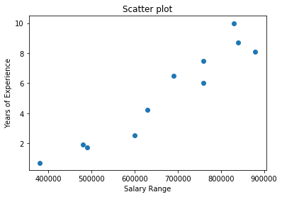

```python
plt.scatter(df.Salary, df.Experience)

plt.xlabel("Salary Range")
plt.ylabel("Years of Experience")
plt.title("Scatter plot")
plt.show()
```

### Inference:

As the years of experience increases , we can see raise in the Salary range. Both are positively correlated.

### Question 2 [3 marks]

#### Analyze the GDP of the country from the data in the file "ex02.txt". Use the appropriate plot to help you derive an inference. You will have to explicitly state your inference what you have found.

```python
df = pd.read_csv("ex02.txt", header=None);
df.columns = ["Year","GDP"]
df.head()
```

|  | Year | GDP |
| --- | --- | --- |
| 0 | 2011 | 8929.5 |
| 1 | 2012 | 8289.1 |
| 2 | 2013 | 10009.9 |
| 3 | 2014 | 11453.6 |
| 4 | 2015 | 13108.3 |

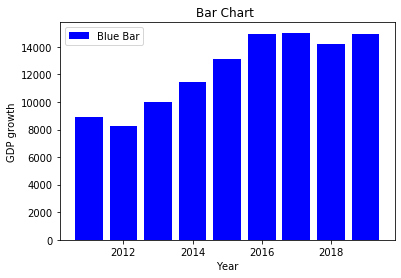

```python
plt.bar(df.Year, df.GDP, label="Blue Bar", color='b')
plt.plot()
plt.xlabel("Year")
plt.ylabel("GDP growth")
plt.title("Bar Chart ")
plt.legend()
plt.show()
```

### Inference:

Can see the growth of GDB after 2015 is maintaing greater than 12000.

### Question 3 [3 marks]

```python
df = pd.read_csv("ex03.txt", header=0);
df.head()
```

|  | City | Year | O2 | CO2 |
| --- | --- | --- | --- | --- |
| 0 | delhi | 2011 | 24.2 | 0.04 |
| 1 | Bangalore | 2011 | 25.2 | 0.03 |
| 2 | delhi | 2013 | 25.3 | 0.05 |
| 3 | Bangalore | 2013 | 24.4 | 0.04 |
| 4 | delhi | 2015 | 26.1 | 0.06 |

### Question 4 [3 marks]

#### The data of number of enrollments to various streams are shown for 2 successive years in the file "ex04.txt". Use the appropriate plot to help you derive an inference. You will have to explicitly state your inference what you have found and state the reason of the significance of the particular plot used.

```python
df = pd.read_csv("ex04.txt", header =0)
df.columns=['Stream','Yr_2018','Yr_2019']
df
```

|  | Stream | Yr_2018 | Yr_2019 |
| --- | --- | --- | --- |
| 0 | Basic Sciences | 23764 | 17213 |
| 1 | Engineering | 66734 | 64398 |
| 2 | Arts | 18033 | 12383 |
| 3 | Commerce | 50876 | 63872 |

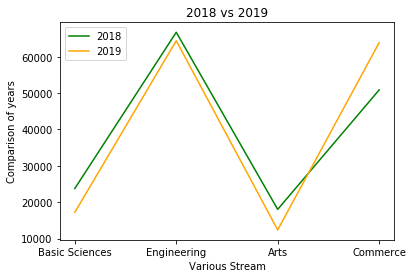

```python
plt.plot(df.Stream, df.Yr_2018, color='g',label=2018)
plt.plot(df.Stream, df.Yr_2019, color='orange',label=2019)
plt.xlabel('Various Stream')
plt.ylabel('Comparison of years')
plt.title('2018 vs 2019')
plt.legend()
plt.show()
```

### Inference:

In 2019 more students shown interest and enrolled to Commerce than 2018.

```python
df = pd.read_csv("ex05.txt", header=None);
df.columns = ["Tweets"]
df.head()
```

|  | Tweets |
| --- | --- |
| 0 | 95 |
| 1 | 85 |
| 2 | 22 |
| 3 | 55 |
| 4 | 62 |

```python
df.info()
```

```
<class 'pandas.core.frame.DataFrame'>
RangeIndex: 31 entries, 0 to 30
Data columns (total 1 columns):
Tweets    31 non-null int64
dtypes: int64(1)
memory usage: 376.0 bytes
```

```python
df.Tweets.describe()
```

```
count    31.000000
mean     52.548387
std      26.408128
min      10.000000
25%      25.500000
50%      55.000000
75%      72.500000
max      95.000000
Name: Tweets, dtype: float64
```

```python
  # get high extreme
q1=25
q2=50
q3=75
whis=1.5
iq = q3 - q1
hi_val = q3 + whis * iq
wisk_hi = np.compress(df.Tweets <= hi_val, df.Tweets)
if len(wisk_hi) == 0 or np.max(wisk_hi) < q3:
    wisk_hi = q3
else:
    wisk_hi = max(wisk_hi)
# get low extreme
lo_val = q1 - whis * iq
wisk_lo = np.compress(df.Tweets >= lo_val, df.Tweets)
if len(wisk_lo) == 0 or np.min(wisk_lo) > q1:
    wisk_lo = q1
else:
    wisk_lo = min(wisk_lo)

print('q1=',wisk_lo)
print ('q3=',wisk_hi)
```

```
q1= 10
q3= 95
```

[output not shown]

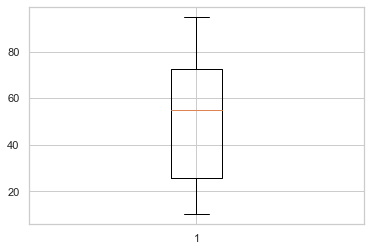

```python
plt.boxplot(df.Tweets, notch=False, sym='+', vert=True, whis=1.5,
        positions=None, widths=None, patch_artist=False,
        bootstrap=None, usermedians=None, conf_intervals=None)
```

```python
quartiles=[]
df.loc[(df['Tweets'] >= 76) & (df['Tweets'] <= 100), 'quartiles'] = 4
df.loc[(df['Tweets'] >= 51) & (df['Tweets'] <= 75), 'quartiles'] = 3
df.loc[(df['Tweets'] >= 26) & (df['Tweets'] <= 50), 'quartiles'] = 2
df.loc[(df['Tweets'] >= 0) & (df['Tweets'] <= 25), 'quartiles'] = 1


df[quartiles]=quartiles
print(df)
```

```
    Tweets  quartiles
0       95        4.0
1       85        4.0
2       22        1.0
3       55        3.0
4       62        3.0
5       45        2.0
6       21        1.0
7       22        1.0
8       34        2.0
9       42        2.0
10      47        2.0
11      29        2.0
12      92        4.0
13      93        4.0
```

[output cut: 17 more lines]

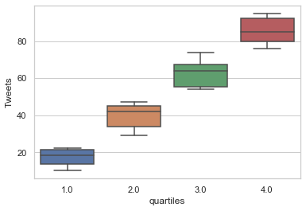

```python
import seaborn as sns
sns.set(style="whitegrid")
#tips = sns.load_dataset("df")
ax = sns.boxplot(x="quartiles", y="Tweets", data=df)
```